# Practical Machine Learning

Kevin O

September 25, 2015

### Summary

The purpose of this exercise is to utilize the Weight Lifting Exercises Dataset found [here] (http://groupware.les.inf.puc-rio.br/har#dataset) in building machine learning models that will predict whether a subject is completing an exercise correctly, or making any of four mistakes, based on data collected through body sensing monitors.

### Data and Libraries

#### Load Data and Library from source locations

```r
library(dplyr)
library(caret)
library(ggplot2)
library(rattle)
library(rpart)
library(gridExtra)
```

Download and read in both the training and test datasets. For both, replace missing values with “NA”

```r
train.url <- "https://d396qusza40orc.cloudfront.net/predmachlearn/pml-training.csv"
download.file(train.url, "pml-training.csv", method = "curl")
train.df <- read.csv("pml-training.csv", header = TRUE, na.strings = c("NA", "NaN", ""))

test.url <-"https://d396qusza40orc.cloudfront.net/predmachlearn/pml-testing.csv"
download.file(test.url, "pml-testing.csv", method = "curl")
test.df <- read.csv("pml-testing.csv", header = TRUE, na.strings = c("NA", "NaN", ""))
```

#### Tidy Data

First, I’ll clean up the data by eliminating columns that contain a significant number of missing values in the train dataset, first from the train dataset, then from the test dataset.

```r
i <- (colSums(is.na(train.df) ))> (.95* nrow (train.df))  ## if more than 95% of the values are missing, eliminate the column
train.clean.df <- train.df[,!i] ## first from the train dataset
test.clean.df <- test.df[,c(head(colnames(train.clean.df),-1),tail(colnames(test.df),1))]  ## and then from the test dataset
train.clean.df <- subset(train.clean.df, select = - X) # eliminate the X variable
test.clean.df <- subset(test.clean.df, select = - X)
```

This step eliminated 100 columns from the dataset.

### Exploratory Analysis

Let’s create a couple of views of whats in the data.

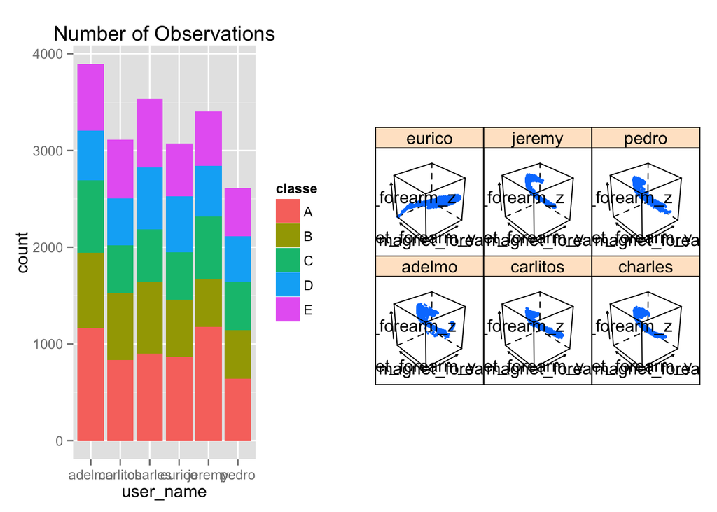

```r
p0 <- ggplot(train.clean.df, aes(user_name, fill=classe)) + geom_bar() + labs(title = "Number of Observations")
p1 <- cloud(magnet_forearm_z ~ magnet_forearm_x + magnet_forearm_y | user_name, data = train.clean.df)
grid.arrange(p0,p1, ncol =2)
```

So we have a good number of observation in each classe for each user_name, and some sense of how one set of 3D variables look by individual.

### Cross Validation

Since there are 19622 observations in the training dataset, I will set up a cross-validation scheme. For purposes of cross validation, I am going to use a 4-fold approach.

```r
set.seed(1776)
inFolds <- createFolds(train.clean.df$classe, k = 4 )
str(inFolds)
```

```
## List of 4
##  $ Fold1: int [1:4906] 10 13 17 19 29 33 35 36 39 40 ...
##  $ Fold2: int [1:4905] 4 7 11 16 21 25 28 41 52 57 ...
##  $ Fold3: int [1:4905] 1 22 23 27 34 44 47 54 55 58 ...
##  $ Fold4: int [1:4906] 2 3 5 6 8 9 12 14 15 18 ...
```

Now lets set up the four test and training sets

```r
train1.clean.df <- train.clean.df[inFolds$Fold1,]
test1.train1 <- train.clean.df[-inFolds$Fold1,]

train2.clean.df <- train.clean.df[inFolds$Fold2,]
test2.train2 <- train.clean.df[-inFolds$Fold2,]

train3.clean.df <- train.clean.df[inFolds$Fold3,]
test3.train3 <- train.clean.df[-inFolds$Fold3,]

train4.clean.df <- train.clean.df[inFolds$Fold4,]
test4.train4 <- train.clean.df[-inFolds$Fold4,]
```

### Model Building and Testing

Now I’m ready to explore building and testing different models.

#### Classification Trees

First, I’ll try the rpart method for predicting with trees.

```r
modelFit0 <- train(classe ~ ., method = "rpart", data = train1.clean.df)
predictions.fit0.train1 <- predict(modelFit0, newdata = train1.clean.df)
confusionMatrix(predictions.fit0.train1,train1.clean.df$classe)$overall
```

```
##       Accuracy          Kappa  AccuracyLower  AccuracyUpper   AccuracyNull
##   6.167958e-01   5.067531e-01   6.030235e-01   6.304289e-01   2.843457e-01
## AccuracyPValue  McnemarPValue
##   0.000000e+00  1.689468e-288
```

#### Random Forest

Next I’ll use a random forest approach.

```r
modelFit1 <- train(classe ~ ., data = train1.clean.df, method = "rf", prox = TRUE)
modelFit1$finalModel
```

```
##
## Call:
##  randomForest(x = x, y = y, mtry = param$mtry, proximity = TRUE)
##                Type of random forest: classification
##                      Number of trees: 500
## No. of variables tried at each split: 41
##
##         OOB estimate of  error rate: 0.47%
## Confusion matrix:
##      A   B   C   D   E  class.error
## A 1394   1   0   0   0 0.0007168459
## B    4 942   3   0   0 0.0073761855
## C    0   2 852   2   0 0.0046728972
## D    0   0   7 796   1 0.0099502488
## E    0   0   0   3 899 0.0033259424
```

```r
predictions.fit1.test1 <- predict(modelFit1, newdata = test1.train1)
confusionMatrix(predictions.fit1.test1, test1.train1$classe)
```

```
## Confusion Matrix and Statistics
##
##           Reference
## Prediction    A    B    C    D    E
##          A 4181    9    0    0    0
##          B    4 2837    4    0    0
##          C    0    2 2559   10    0
##          D    0    0    3 2401   12
##          E    0    0    0    1 2693
##
## Overall Statistics
##
##                Accuracy : 0.9969
##                  95% CI : (0.9959, 0.9978)
##     No Information Rate : 0.2844
##     P-Value [Acc > NIR] : < 2.2e-16
##
##                   Kappa : 0.9961
##  Mcnemar's Test P-Value : NA
##
## Statistics by Class:
##
##                      Class: A Class: B Class: C Class: D Class: E
## Sensitivity            0.9990   0.9961   0.9973   0.9954   0.9956
## Specificity            0.9991   0.9993   0.9990   0.9988   0.9999
## Pos Pred Value         0.9979   0.9972   0.9953   0.9938   0.9996
## Neg Pred Value         0.9996   0.9991   0.9994   0.9991   0.9990
## Prevalence             0.2844   0.1935   0.1744   0.1639   0.1838
## Detection Rate         0.2841   0.1928   0.1739   0.1632   0.1830
## Detection Prevalence   0.2847   0.1933   0.1747   0.1642   0.1831
## Balanced Accuracy      0.9991   0.9977   0.9981   0.9971   0.9977
```

I’m getting a nearly 99.7% accuracy with very high sensitivity and specificity values for all classes on the test1 dataset.

#### Boosting

I’ll try another model, this time using boosting, on my second training dataset

```r
modelFit2 <- train(classe ~., method = "gbm", data = train2.clean.df, verbose = FALSE)
modelFit2
```

```
## Stochastic Gradient Boosting
##
## 4905 samples
##   58 predictor
##    5 classes: 'A', 'B', 'C', 'D', 'E'
##
## No pre-processing
## Resampling: Bootstrapped (25 reps)
## Summary of sample sizes: 4905, 4905, 4905, 4905, 4905, 4905, ...
## Resampling results across tuning parameters:
##
##   interaction.depth  n.trees  Accuracy   Kappa      Accuracy SD
##   1                   50      0.8255445  0.7785039  0.012238329
##   1                  100      0.8903818  0.8611695  0.007691926
##   1                  150      0.9200562  0.8987240  0.007142066
##   2                   50      0.9515375  0.9386152  0.006480075
##   2                  100      0.9811260  0.9761104  0.004392354
##   2                  150      0.9887872  0.9858132  0.002888273
##   3                   50      0.9764666  0.9702055  0.004337931
##   3                  100      0.9904301  0.9878922  0.002370660
##   3                  150      0.9924059  0.9903935  0.002206302
##   Kappa SD
##   0.015557615
##   0.009711636
##   0.009048910
##   0.008228280
##   0.005556270
##   0.003643297
##   0.005495359
##   0.002991140
##   0.002778539
##
## Tuning parameter 'shrinkage' was held constant at a value of 0.1
##
## Tuning parameter 'n.minobsinnode' was held constant at a value of 10
## Accuracy was used to select the optimal model using  the largest value.
## The final values used for the model were n.trees = 150,
##  interaction.depth = 3, shrinkage = 0.1 and n.minobsinnode = 10.
```

```r
predictions.fit2.test2 <- predict(modelFit2, newdata = test2.train2)
confusionMatrix(predictions.fit2.test2, test2.train2$classe)
```

```
## Confusion Matrix and Statistics
##
##           Reference
## Prediction    A    B    C    D    E
##          A 4183   16    0    0    0
##          B    2 2826    2    0    2
##          C    0    5 2545    5    0
##          D    0    0   20 2372    7
##          E    0    0    0   35 2697
##
## Overall Statistics
##
##                Accuracy : 0.9936
##                  95% CI : (0.9922, 0.9948)
##     No Information Rate : 0.2844
##     P-Value [Acc > NIR] : < 2.2e-16
##
##                   Kappa : 0.9919
##  Mcnemar's Test P-Value : NA
##
## Statistics by Class:
##
##                      Class: A Class: B Class: C Class: D Class: E
## Sensitivity            0.9995   0.9926   0.9914   0.9834   0.9967
## Specificity            0.9985   0.9995   0.9992   0.9978   0.9971
## Pos Pred Value         0.9962   0.9979   0.9961   0.9887   0.9872
## Neg Pred Value         0.9998   0.9982   0.9982   0.9968   0.9992
## Prevalence             0.2844   0.1934   0.1744   0.1639   0.1839
## Detection Rate         0.2842   0.1920   0.1729   0.1612   0.1833
## Detection Prevalence   0.2853   0.1924   0.1736   0.1630   0.1856
## Balanced Accuracy      0.9990   0.9961   0.9953   0.9906   0.9969
```

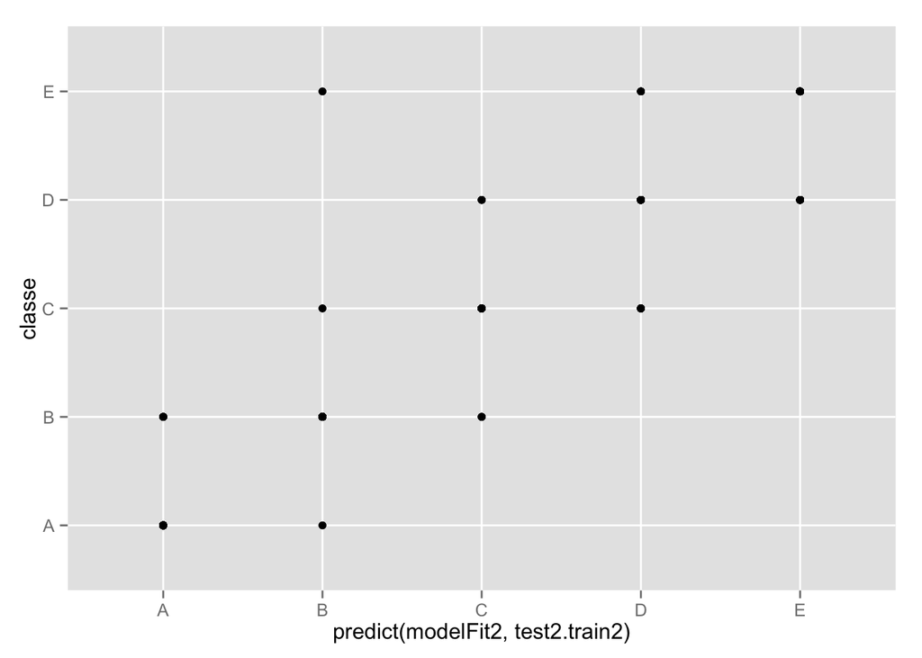

```r
qplot(predict(modelFit2,test2.train2), classe, data = test2.train2)
```

This model also delivers excellent results, with also a nearly 99.5% accuracy. **I will use this model for my results.**

#### Out of Sample Error

I’ll apply the boosting model to each of the other two test datasets in my cross-validation samples. This will provide 3 point estimates for the out of sample error calculation.

```r
predictions.fit2.test3 <- predict(modelFit2, newdata = test3.train3)
print("Test 3")
```

```
## [1] "Test 3"
```

```r
confusionMatrix(predictions.fit2.test3, test3.train3$classe)$overall
```

```
##       Accuracy          Kappa  AccuracyLower  AccuracyUpper   AccuracyNull
##      0.9958551      0.9947569      0.9946789      0.9968281      0.2843650
## AccuracyPValue  McnemarPValue
##      0.0000000            NaN
```

```r
predictions.fit2.test4 <- predict(modelFit2, newdata = test4.train4)
print("Test 4")
```

```
## [1] "Test 4"
```

```r
confusionMatrix(predictions.fit2.test4, test4.train4$classe)$overall
```

```
##       Accuracy          Kappa  AccuracyLower  AccuracyUpper   AccuracyNull
##      0.9951753      0.9938968      0.9939182      0.9962300      0.2843843
## AccuracyPValue  McnemarPValue
##      0.0000000            NaN
```

**So I estimate the out of sample error rate to be 1 - average(accuracy rates of the three test samples) = 0.0051189** !

### Applying the Best Model to the original course project test dataset

Using the Boosting model, I then predicted the results for the test dataset downloaded from the course website, and submitted my answers. All were correct!

```r
predictionsFit2 <- predict(modelFit2, test.clean.df)
predictionsFit2
```

```
##  [1] B A B A A E D B A A B C B A E E A B B B
## Levels: A B C D E
```